# Project: California COVID-19 Data EDA and Univariate Models

The MLR with correlated errors model is calculated using the smoothed version of the new cases data. We first need to forecast new cases, so that we can include them in our prediction of the hospitalizations forecast.

```r
#Cut out the zeros at the beginning of Totalhosp and create equal length variable for new cases that lines up with hospital data
Totalhosp1 <- Totalhosp[12:119]
newcases_7dayavg1 <- CA$newcases_7dayavg[5:112]
```

New cases shows a similar trend to hospitalizations in the last month. To maintain consistency, we’ll use only the last month of data as done in the non-stationary modeling of hospitalizations, and create a model that continues the increasing trend.

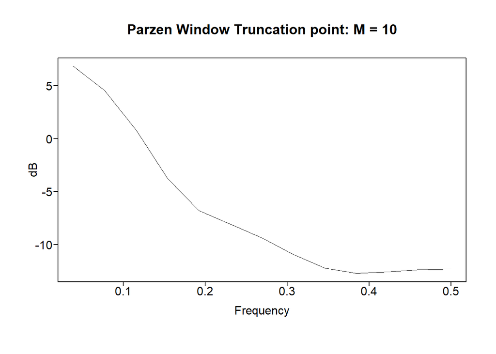

```
## $freq
##  [1] 0.03846154 0.07692308 0.11538462 0.15384615 0.19230769 0.23076923
##  [7] 0.26923077 0.30769231 0.34615385 0.38461538 0.42307692 0.46153846
## [13] 0.50000000
##
## $pzgram
##  [1]   6.8399258   4.5668340   0.7981836  -3.7688205  -6.8129332  -8.0822166
##  [7]  -9.3866117 -10.9297358 -12.2318601 -12.7297715 -12.6000650 -12.3819517
## [13] -12.2935773
```

```r
#Use only approx last month of new case data
newcases_7dayavg2 <- newcases_7dayavg[83:108]

#Model New Cases
parzen.wge(newcases_7dayavg2) #Data is smoothed by averaging to remove seasonality - parzen plot is more evidence of successful transformation
```

```r
#difference the data twice for the increasing linear trend
newcases_7dayavg2_d1 <- artrans.wge(newcases_7dayavg2, phi.tr = 1)
```

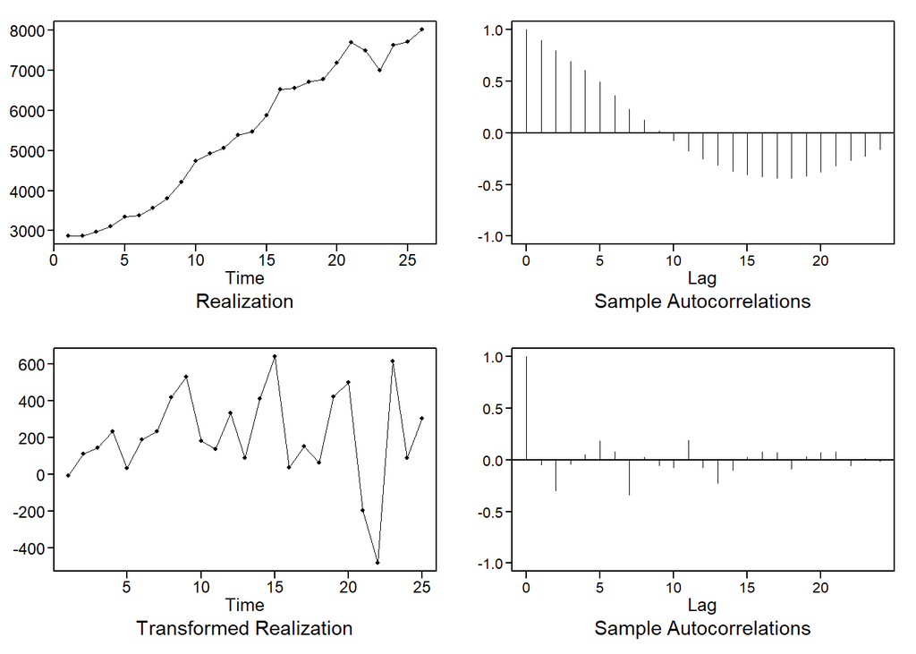

```r
newcases_7dayavg2_d2 <- artrans.wge(newcases_7dayavg2_d1, phi.tr = 1)
```

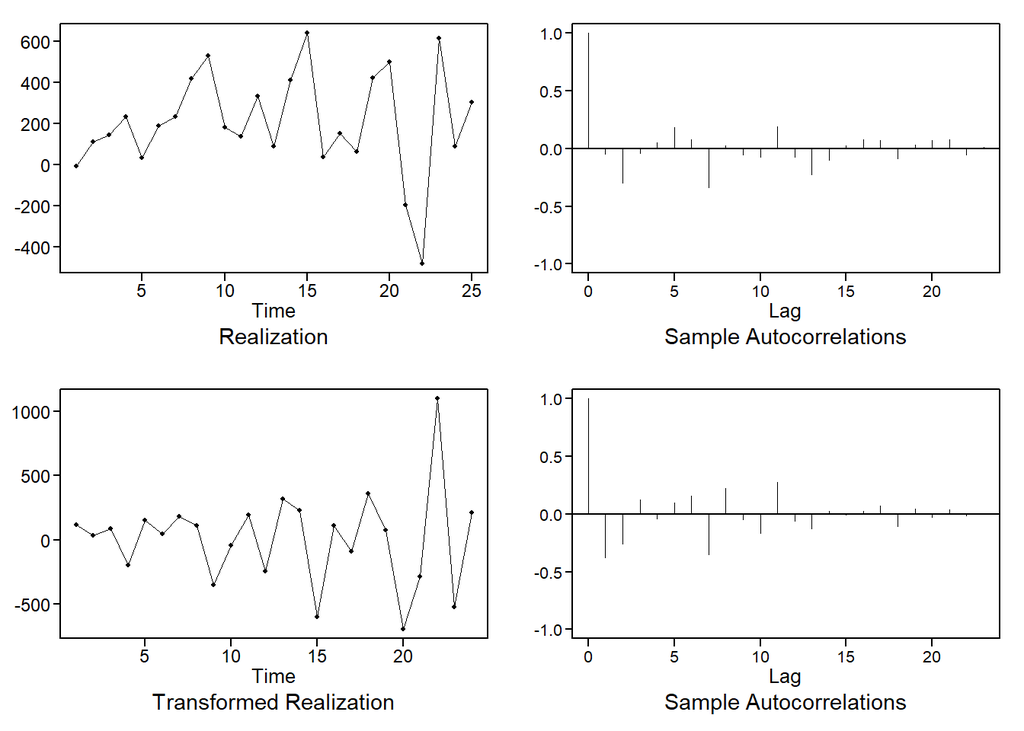

```r
#check for white noise
acf(newcases_7dayavg2_d2) #appears to be white noise after second difference
lj10 <- ljung.wge(newcases_7dayavg2_d2, K=10)
```

```
## Obs -0.3746032 -0.261266 0.1253135 -0.04341744 0.1014342 0.1564863 -0.3524986 0.2215689 -0.04991159 -0.1646908
```

```r
lj10$pval
```

```
## [1] 0.1234309
```

```r
lj20 <- ljung.wge(newcases_7dayavg2_d2, K=20)
```

```
## Obs -0.3746032 -0.261266 0.1253135 -0.04341744 0.1014342 0.1564863 -0.3524986 0.2215689 -0.04991159 -0.1646908 0.2797824 -0.06330549 -0.1231133 0.02580619 -0.009300202 0.02385994 0.06879511 -0.1053571 0.04606625 -0.02904691
```

```r
lj20$pval
```

```
## [1] 0.3332923
```

```r
#both ljung-box tests fail to reject H0 of white noise after d=2. No need to fit a stationary component to the model

#The final model is a simple ARIMA(0,0,0) with d=2
f_cases <- fore.aruma.wge(newcases_7dayavg1, d=2, n.ahead = 7, lastn = FALSE, limits = FALSE)
```

[figure not shown]

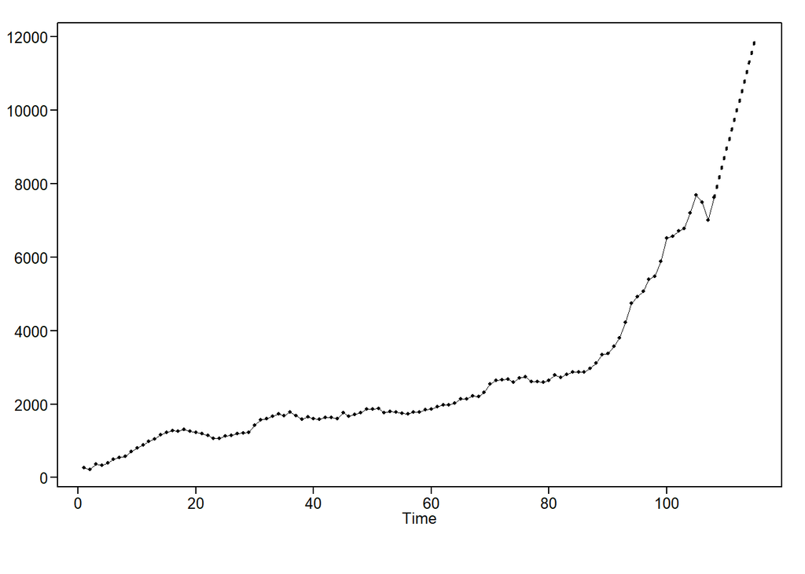

It might not make much sense to include new cases forecast as a predictor when the model used to produce the forecast is a simple line. It likely defeats the purpose of including a second variable. We could also try an mlp model to see if it comes up with something worth using as an exogenous variable - an ensemble calculated from the mean of generated mlp models may be the best way to come up with a short term new cases forecast that isnt biased by expectations.

```r
newcases_7dayavg2_ts <- ts(newcases_7dayavg2) #create time series object
fit_mlp_cases = mlp(newcases_7dayavg2_ts, reps = 50, comb = "mean") #mlp fit
fit_mlp_cases
```

```
## MLP fit with 5 hidden nodes and 50 repetitions.
## Series modelled in differences: D1.
## Univariate lags: (2)
## Forecast combined using the mean operator.
## MSE: 31580.0092.
```

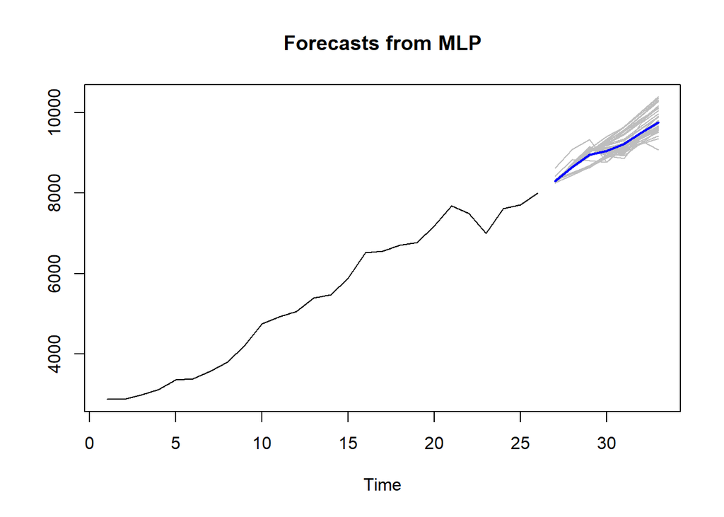

```r
fore_mlp_cases <- forecast(fit_mlp_cases, h=7) #univariate 1-week mlp forecast
plot(fore_mlp_cases)
```

This forecast looks like a good one to use in the hospitalizations forecast.

The next step is to generate the MLR model that predicts hospitalizations.

2. Check for lag between hospitalizations and new cases

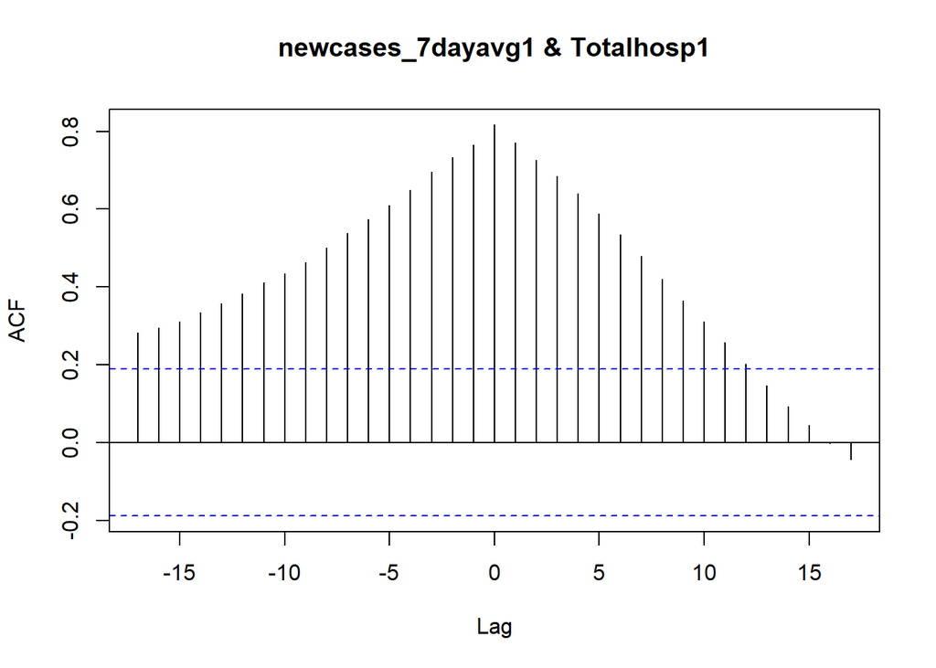

```r
ccf(newcases_7dayavg1, Totalhosp1) #no lagging needed based on ccf plot
```

3. Fit a linear model predicting hospitalized patients

```r
mlr_fit <- lm(Totalhosp1~newcases_7dayavg1)
```

4. View the residuals of the linear model

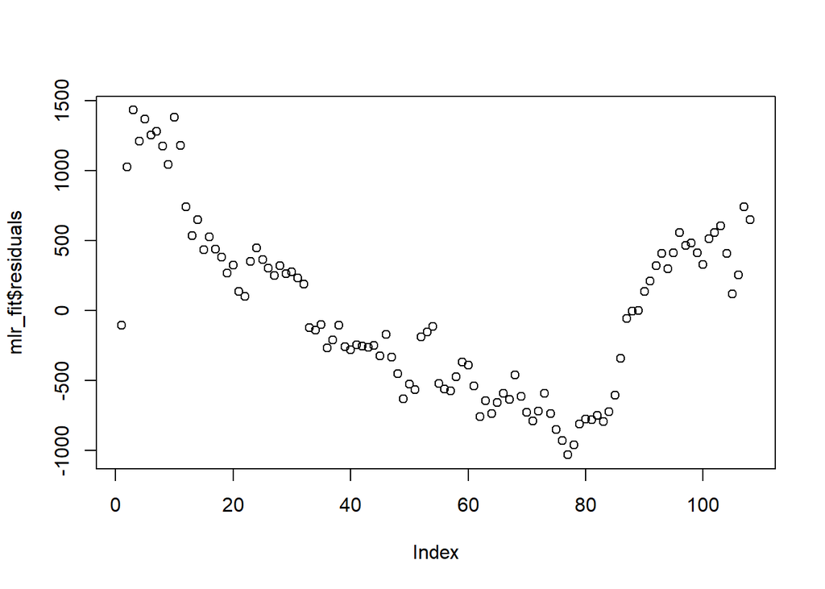

```r
plot(mlr_fit$residuals)
```

5. Fit the residuals

```r
aic5.wge(mlr_fit$residuals)
```

```
## ---------WORKING... PLEASE WAIT...
##
##
## Five Smallest Values of  aic
```

```
##       p    q        aic
## 5     1    1   10.44648
## 10    3    0   10.45518
## 7     2    0   10.45564
## 8     2    1   10.46386
## 6     1    2   10.46571
```

```r
#low p/q models as expected. The top pick of ARMA(1,1) should be reasonable
fit1 = arima(Totalhosp1, order=c(1,0,1), xreg=newcases_7dayavg1)
fit1
```

```
##
## Call:
## arima(x = Totalhosp1, order = c(1, 0, 1), xreg = newcases_7dayavg1)
##
## Coefficients:
##          ar1     ma1  intercept  newcases_7dayavg1
##       0.9804  0.3141   5037.298             0.1824
## s.e.  0.0257  0.0993   1002.218             0.1369
##
## sigma^2 estimated as 30755:  log likelihood = -713.22,  aic = 1436.43
```

The AIC of this model is 1436.

6. Check the residuals of final model

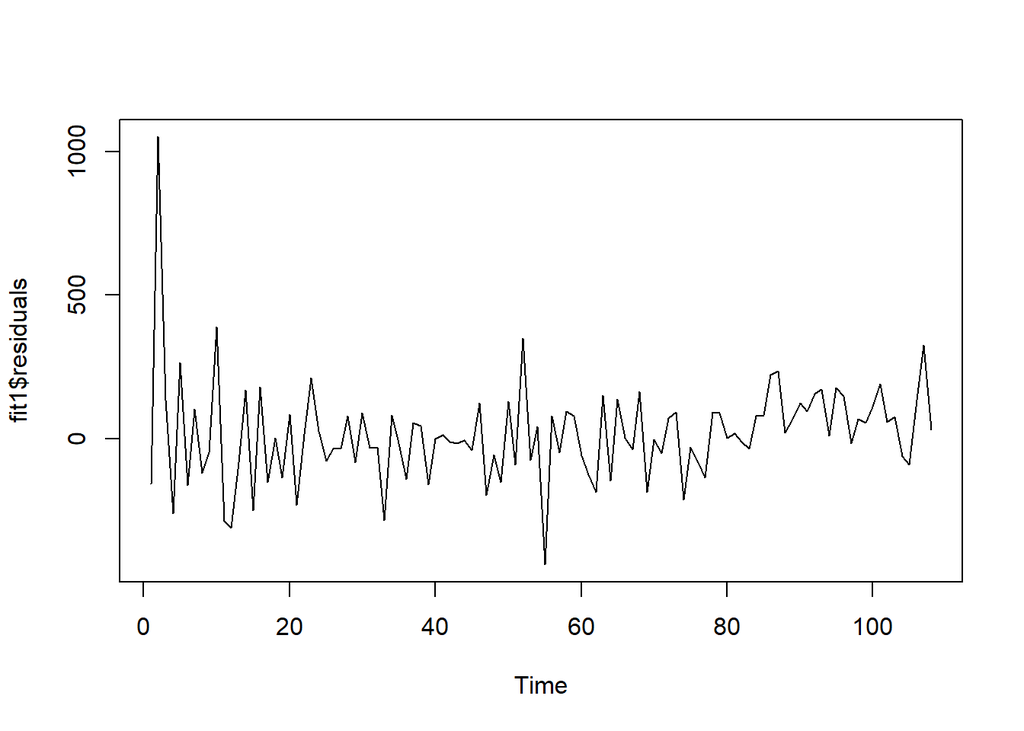

```r
plot(fit1$residuals)
```

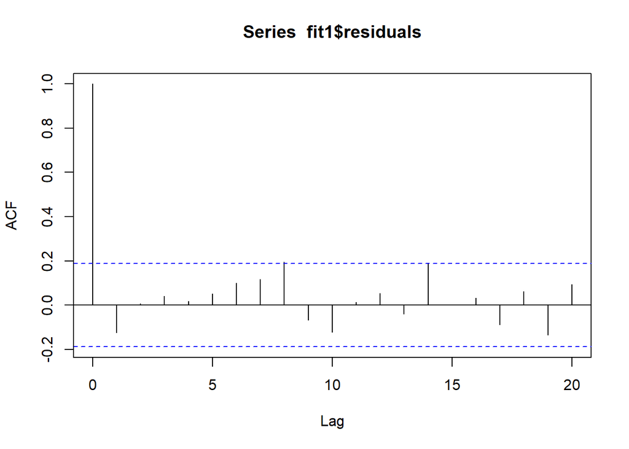

```r
acf(fit1$residuals)
```

```r
lj24 <- ljung.wge(fit1$residuals, p=1, q=1)
```

```
## Obs -0.1255186 0.005970606 0.04022545 0.01803424 0.05116252 0.09885327 0.1164257 0.1947251 -0.06844523 -0.1223411 0.01329362 0.05266574 -0.03984679 0.1887202 -0.0003049872 0.03184258 -0.08813581 0.06042104 -0.1355143 0.09363089 0.1272651 0.09310402 -0.06917536 -0.02345276
```

```r
lj24$pval
```

```
## [1] 0.2360875
```

```r
lj48 <- ljung.wge(fit1$residuals, p=1, q=1, K=48)
```

```
## Obs -0.1255186 0.005970606 0.04022545 0.01803424 0.05116252 0.09885327 0.1164257 0.1947251 -0.06844523 -0.1223411 0.01329362 0.05266574 -0.03984679 0.1887202 -0.0003049872 0.03184258 -0.08813581 0.06042104 -0.1355143 0.09363089 0.1272651 0.09310402 -0.06917536 -0.02345276 -0.05108337 -0.02155796 …
```

```r
lj48$pval
```

```
## [1] 0.380569
```

The acf does not show significant autocorrelation and the Ljung-Box tests failed to reject H0 that the residuals are white noise.

### Forecast Hospitalizations with MLR w/ Correlated Errors with 7 Day Avg New Cases

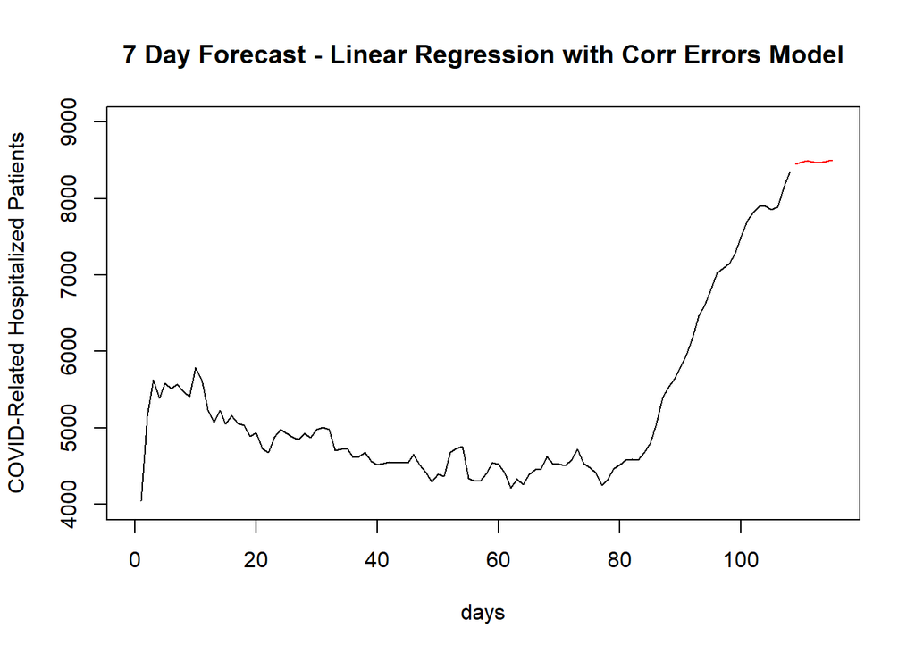

```r
next7 = data.frame(new_cases_avg = fore_mlp_cases$mean)
f_mlr <- predict(fit1, newxreg = next7, n.ahead = 7)

plot(seq(1,108,1), Totalhosp1, type = "l",xlim = c(0,115),ylim=c(4000,9000), xlab="days", ylab = "COVID-Related Hospitalized Patients", main = "7 Day Forecast - Linear Regression with Corr Errors Model")
lines(seq(109,115,1), f_mlr$pred, type = "l", col = "red")
```

### Add time as a Variable in MLR

Based on previous analysis we obviously believe that the data is dependent on time (there is a trend) so time should be added to the linear model as a variable. We can compare the aic to the previous model with time excluded.

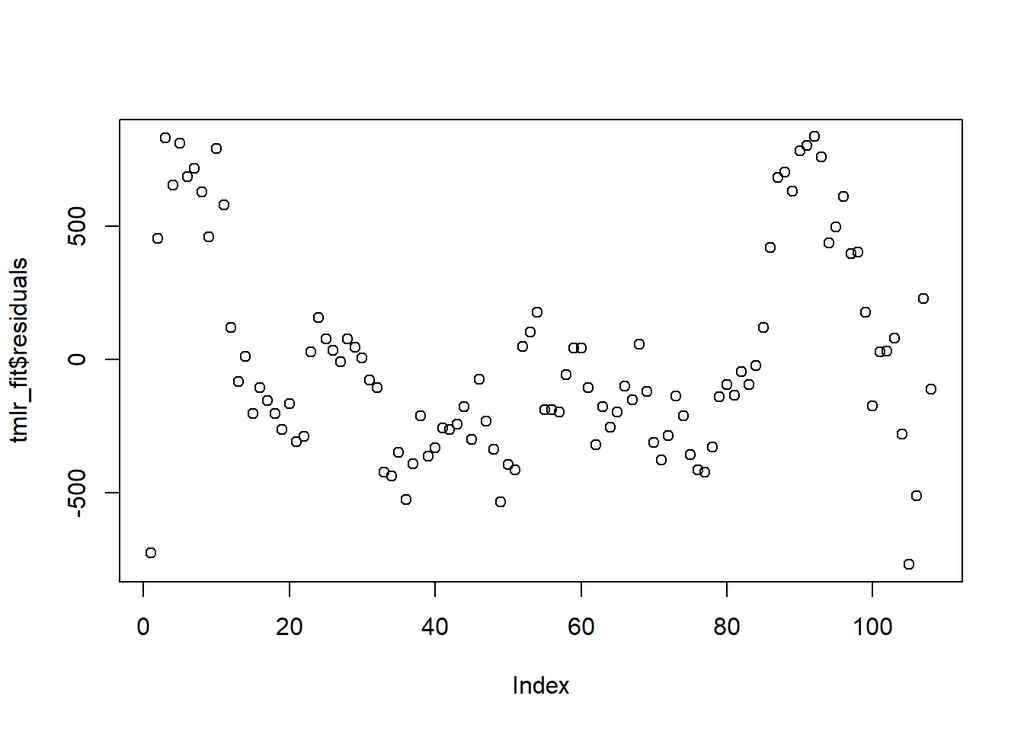

```r
#fit linear model for predicting hospitalization, including time as a variable
Time <- seq(1,108,1)
tmlr_fit <- lm(Totalhosp1~newcases_7dayavg1+Time)
plot(tmlr_fit$residuals)
```

```r
#fit residuals
aic5.wge(tmlr_fit$residuals)
```

```
## ---------WORKING... PLEASE WAIT...
##
##
## Five Smallest Values of  aic
```

```
##       p    q        aic
## 5     1    1   10.65776
## 10    3    0   10.66787
## 6     1    2   10.67013
## 8     2    1   10.67525
## 7     2    0   10.67649
```

```r
#The top pick is ARMA(1,1) again
fit1t = arima(Totalhosp1, order=c(1,0,1), xreg=cbind(newcases_7dayavg1,Time))
fit1t #aic =1433, slightly better with time included
```

```
##
## Call:
## arima(x = Totalhosp1, order = c(1, 0, 1), xreg = cbind(newcases_7dayavg1, Time))
##
## Coefficients:
##          ar1     ma1  intercept  newcases_7dayavg1     Time
##       0.9736  0.3171  3556.8976             0.0789  31.9194
## s.e.  0.0203  0.0955   946.7531             0.1204  16.3042
##
## sigma^2 estimated as 29525:  log likelihood = -710.87,  aic = 1433.73
```

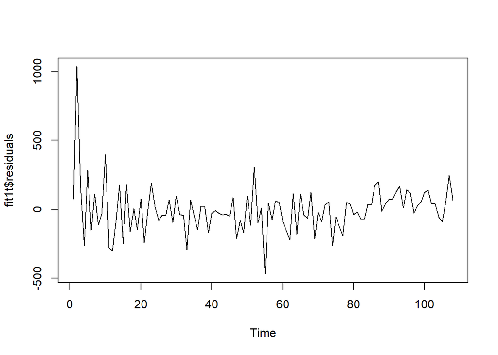

```r
#check residuals of model
plot(fit1t$residuals)
```

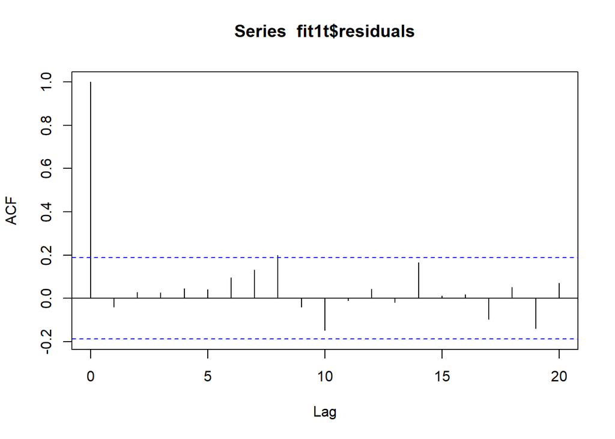

```r
acf(fit1t$residuals) #appears to have no autocorrelation
```

```r
lj24 <- ljung.wge(fit1t$residuals, p=1, q=1)
```

```
## Obs -0.03926346 0.02864523 0.02537815 0.04551755 0.03999161 0.09442141 0.1322683 0.1980511 -0.03952732 -0.1478463 -0.01064909 0.04227483 -0.01795223 0.1660975 0.009965204 0.01774608 -0.09759234 0.05039035 -0.1401209 0.06995263 0.1272211 0.1065629 -0.07193778 -0.03632591
```

```r
lj24$pval
```

```
## [1] 0.3109216
```

```r
lj48 <- ljung.wge(fit1t$residuals, p=1, q=1, K=48)
```

```
## Obs -0.03926346 0.02864523 0.02537815 0.04551755 0.03999161 0.09442141 0.1322683 0.1980511 -0.03952732 -0.1478463 -0.01064909 0.04227483 -0.01795223 0.1660975 0.009965204 0.01774608 -0.09759234 0.05039035 -0.1401209 0.06995263 0.1272211 0.1065629 -0.07193778 -0.03632591 -0.05790954 -0.02761053 0.…
```

```r
lj48$pval
```

```
## [1] 0.3938294
```

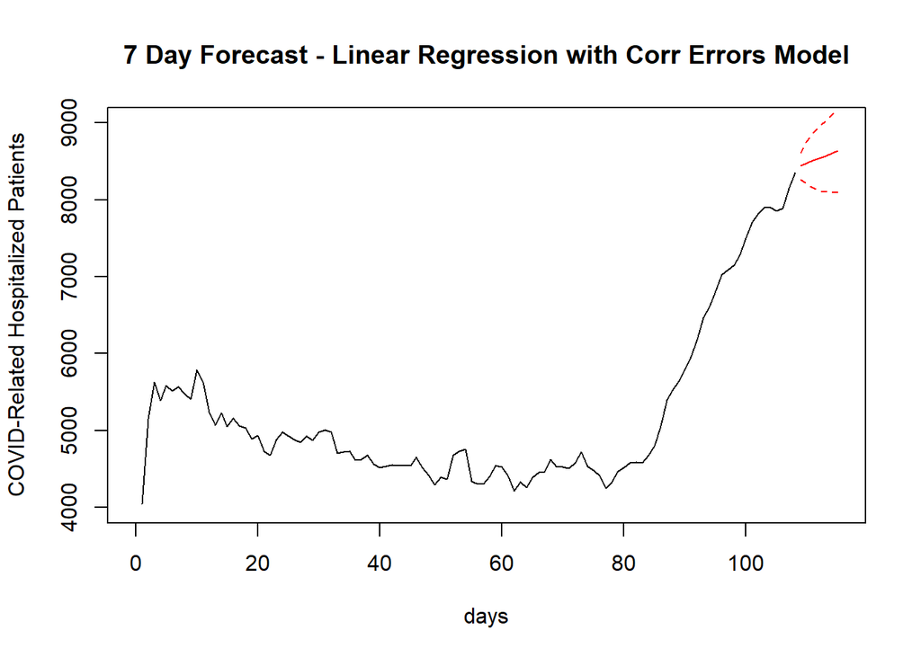

```r
#Ljung-Box test fails to reject H0 - no evidence against white noise

#forecast hospitalizations using prior forecast of 7 day avg new cases by mlp model
next7 = data.frame(new_cases_avg = fore_mlp_cases$mean, Time = seq(109,115,1))
f_mlr2 <- predict(fit1t, newxreg = next7, n.ahead = 7)

plot(seq(1,108,1), Totalhosp1, type = "l",xlim = c(0,115),ylim=c(4000,9000), xlab="days", ylab = "COVID-Related Hospitalized Patients", main = "7 Day Forecast - Linear Regression with Corr Errors Model")
lines(seq(109,115,1), f_mlr2$pred, type = "l", col = "red")
lines(seq(109,115,1), (f_mlr2$pred+f_mlr2$se), type = "l", col = "red",lty = 2)
lines(seq(109,115,1), (f_mlr2$pred-f_mlr2$se), type = "l", col = "red",lty = 2)
```

The model with time included as a variable in the MLR had a slightly lower aic, but the forecast is really anyone’s guess. For a seven-day prediction, the second (with time included in linear model variables) looks like a reasonable extention of the current trend. Again, this model is not suitable for a 90 day forecast based on our expectations.

The model was run again reserving the last 7 observations for calculating the ASE against a forecast.

```r
Totalhosp1_train <- Totalhosp1[1:101]
Totalhosp1_test <- Totalhosp1[102:108]

fit1t_test = arima(Totalhosp1_train, order=c(1,0,1), xreg=cbind(newcases_7dayavg1[1:101],Time[1:101]))
next7_test = data.frame(new_cases_avg = newcases_7dayavg[102:108], time_t = Time[102:108])
f_mlr2_test <- predict(fit1t_test, newxreg = next7, n.ahead = 7)

ASE = mean((Totalhosp1_test - f_mlr2_test$pred)^2)
ASE
```

```
## [1] 171955.1
```

The plot of this overlayed forecast to calculate the ASE shows how this model doesn’t have quite as severe an incline, so it doesn’t depart as far from the dip at the end of the data.

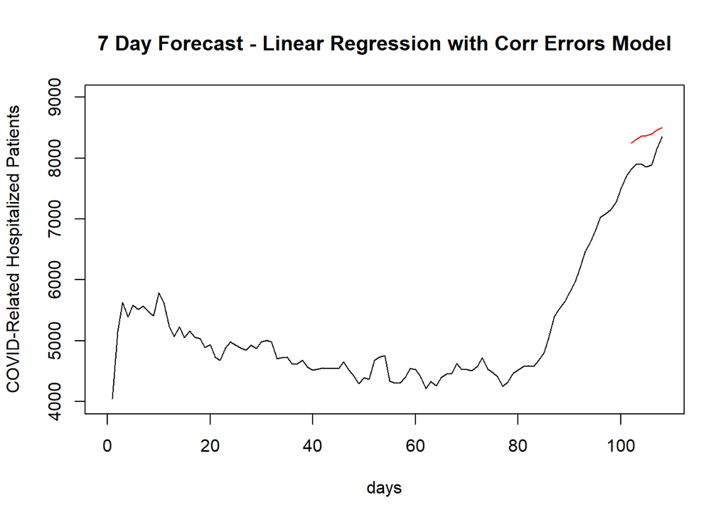

```r
plot(seq(1,108,1), Totalhosp1, type = "l",xlim = c(0,108),ylim=c(4000,9000), xlab="days", ylab = "COVID-Related Hospitalized Patients", main = "7 Day Forecast - Linear Regression with Corr Errors Model")
lines(seq(102,108,1), f_mlr2_test$pred, type = "l", col = "red")
```

### California: Vector AR Models

We can use the same variables to model using VAR.

1. Create matrix of variables

```r
var_matrix1 <- cbind(newcases_7dayavg1, Totalhosp1)
```

2. Model Hospitalizations and New Cases with VAR

We will model the data as if it is stationary; this might help against generating models with exponential inclines.

```r
VARselect(var_matrix1, lag.max = 10, type = "both") #AIC picks 9, BIC picks 1
```

```
## $selection
## AIC(n)  HQ(n)  SC(n) FPE(n)
##      9      1      1      8
##
## $criteria
##                   1            2            3            4            5
## AIC(n) 1.938112e+01 1.943825e+01 1.935951e+01 1.934788e+01 1.942175e+01
## HQ(n)  1.946647e+01 1.956627e+01 1.953021e+01 1.956126e+01 1.967781e+01
## SC(n)  1.959213e+01 1.975477e+01 1.978155e+01 1.987542e+01 2.005481e+01
## FPE(n) 2.613073e+08 2.767298e+08 2.558848e+08 2.531024e+08 2.727930e+08
##                   6            7            8            9           10
## AIC(n) 1.930603e+01 1.925005e+01 1.911073e+01 1.910819e+01 1.914237e+01
## HQ(n)  1.960477e+01 1.959146e+01 1.949481e+01 1.953495e+01 1.961181e+01
## SC(n)  2.004460e+01 2.009412e+01 2.006031e+01 2.016328e+01 2.030297e+01
## FPE(n) 2.433398e+08 2.305421e+08 2.010691e+08 2.012009e+08 2.090171e+08
```

```r
vfit1_1 <- VAR(var_matrix1,p=9,type = "both")
```

### Forecast using VAR model

```r
#7 Day forecast
vpreds1_7 <- predict(vfit1_1,n.ahead = 7)
vpreds1_7$fcst$Totalhosp1
```

```
##          fcst    lower     upper       CI
## [1,] 8561.152 8328.223  8794.080 232.9283
## [2,] 8512.702 8184.889  8840.514 327.8128
## [3,] 8682.112 8292.366  9071.858 389.7459
## [4,] 8938.472 8504.740  9372.205 433.7322
## [5,] 9202.291 8721.534  9683.048 480.7570
## [6,] 9250.180 8724.203  9776.156 525.9764
## [7,] 9481.318 8887.768 10074.868 593.5497
```

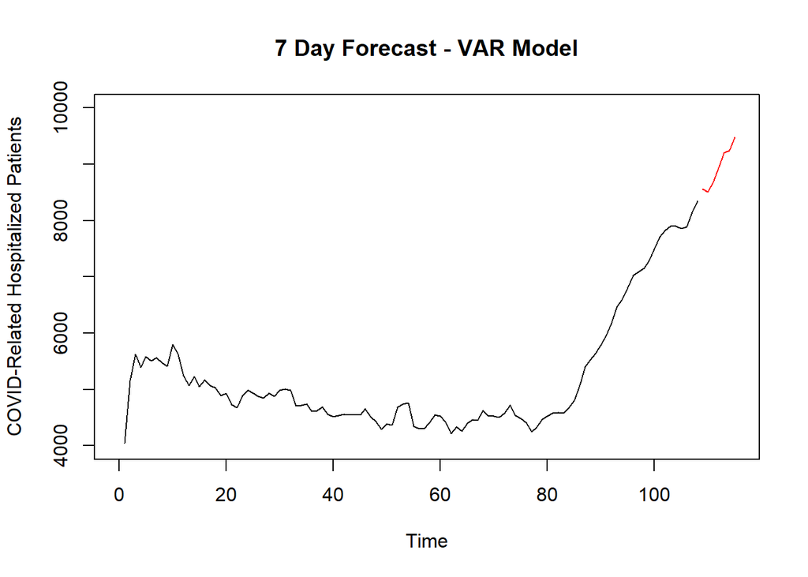

```r
#Plot 7 day forecast
plot(Time, Totalhosp1, type = "l",xlim = c(0,115),  ylim = c(4000,10000), ylab = "COVID-Related Hospitalized Patients", main = "7 Day Forecast - VAR Model")
lines(seq(109,115,1), vpreds1_7$fcst$Totalhosp1[,1], type = "l", col = "red")
```

Based on the data we have, the model created an exponential incline which again, we’ll consider a 90 day forecast based on this model to be unrealistic based on our expectations.

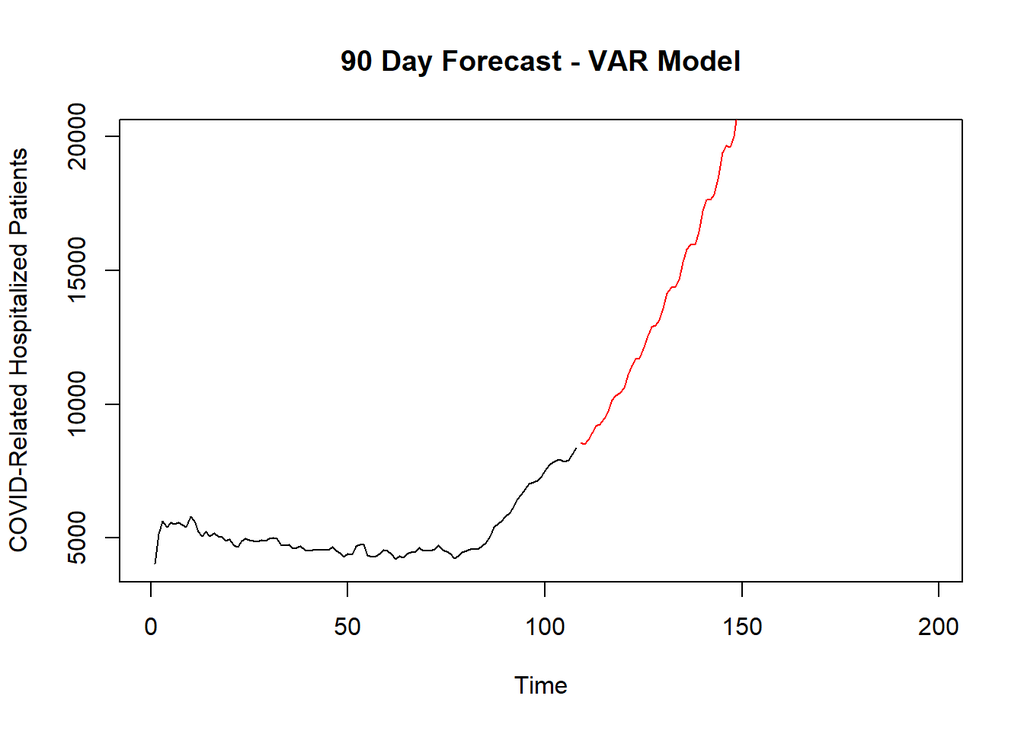

```r
#90 Day forecast
vpreds1_90 <- predict(vfit1_1,n.ahead = 90)

#Plot 7 day forecast
plot(Time, Totalhosp1, type = "l",xlim = c(0,198),  ylim = c(4000,20000), ylab = "COVID-Related Hospitalized Patients", main = "90 Day Forecast - VAR Model")
lines(seq(109,198,1), vpreds1_90$fcst$Totalhosp1[,1], type = "l", col = "red")
```

As with the MLR model, we can backtrack and reserve the last 7 points to calculate ASE.

```r
var_matrix1_train <- cbind(newcases_7dayavg1[1:101], Totalhosp1[1:101])
var_matrix1_test <- cbind(newcases_7dayavg1[102:108], Totalhosp1[102:108])

vfit1_train <- VAR(var_matrix1_train,p=9,type = "both")
vpreds1_train <- predict(vfit1_train,n.ahead = 7)

ASE = mean((Totalhosp1_test - vpreds1_train$fcst$y2[,1])^2)
ASE
```

```
## [1] 1240595
```

we can see that the ASE is much higher for this model because it generated a rapidly increasing trend that missed the dip at the end of the data.

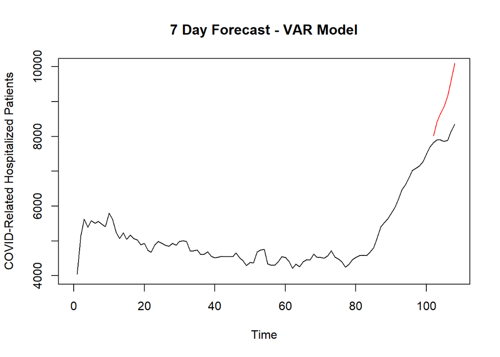

```r
plot(Time, Totalhosp1, type = "l",xlim = c(0,108),  ylim = c(4000,10000), ylab = "COVID-Related Hospitalized Patients", main = "7 Day Forecast - VAR Model")
lines(seq(102,108,1), vpreds1_train$fcst$y2[,1], type = "l", col = "red")
```

### California: Multivariate MLP Models

We can start with the base mlp function as we did in the univariate analysis.

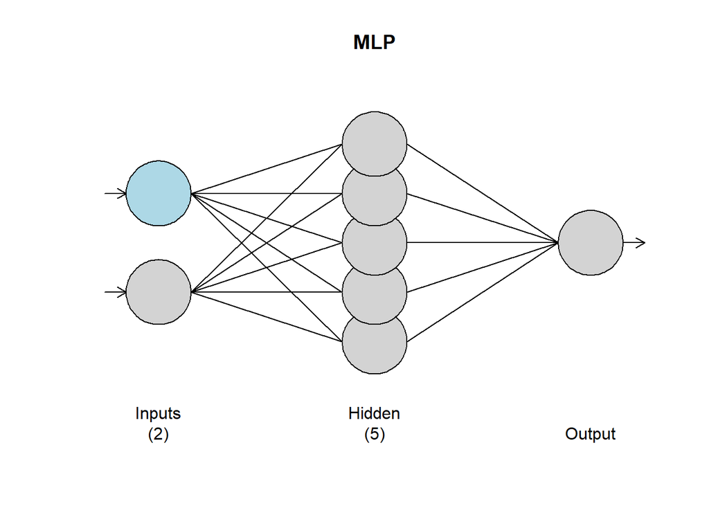

```r
#create time series objects
tsth <- ts(Totalhosp1)
tsnc <- ts(newcases_7dayavg1)

#model hospitalizations with mlp
tsnc_df <- data.frame(tsnc)
mlp_fit_mult <- mlp(tsth, reps = 50, comb = "median", xreg = tsnc_df)
plot(mlp_fit_mult)
```

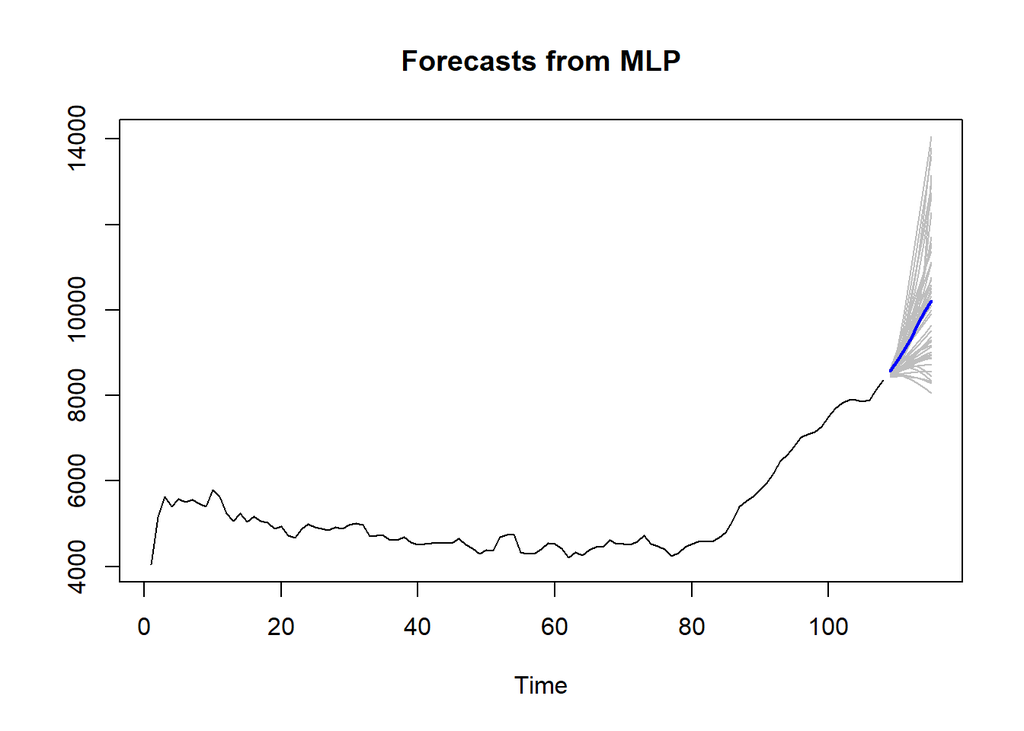

```r
#add new cases forecast from earlier to use in multivariate mlp forecast
case_f <- as.numeric(fore_mlp_cases$mean)
case_df <- data.frame(c(newcases_7dayavg1, case_f))

#add the new df to the multivariate forecast
mlp_fore_mult <- forecast(mlp_fit_mult, h=7, xreg = case_df)
plot(mlp_fore_mult)
```

The 7 day forecast does no look unreasonable, but we can tune the parameters to optimize by lowest ASE.

### Multivariate MLP with tuned Hyperparameters

As with the univariate MLP, we can tune the hyperparameters using windowed ASE to get an optimized model.

```r
data_train.u <- data.frame(TotalHosp_wase1 = Totalhosp1[1:88], newcases_7dayavg1_wase1 = newcases_7dayavg1[1:88])
data_test.u <- data.frame(TotalHosp_wase1 = Totalhosp1[89:108], newcases_7dayavg1_wase1 = newcases_7dayavg1[89:108])
```

```r
# search for best NN hyperparameters in given grid
model.u = tswgewrapped::ModelBuildNNforCaret$new(data = data_train.u, var_interest = "TotalHosp_wase1", search = 'random', tuneLength = 5, parallel = TRUE, batch_size = 50, h = 7, verbose = 1)
```

```
## - Total Time for training: : 5.96 sec elapsed
```

- The ASEs associated with the grid of hyperparameters is shown in the table below.

```r
res.u <- model.u$summarize_hyperparam_results()
res.u
```

```
##   reps hd allow.det.season     RMSE      ASE   RMSESD    ASESD
## 1   10  2             TRUE 191.6448 39467.11 57.33450 22970.72
## 2   11  3            FALSE 206.1944 46434.87 68.57449 29678.06
## 3   16  1            FALSE 184.3065 36725.75 57.51728 20639.74
## 4   16  3             TRUE 207.7638 47263.78 70.12560 30760.63
## 5   22  3            FALSE 205.9433 46259.84 67.94564 29964.44
```

- Windowed ASE: The best hyperparameters:

```r
best.u <- model.u$summarize_best_hyperparams()
best.u
```

```
##   reps hd allow.det.season
## 3   16  1            FALSE
```

The ASE of the model using these hyperparameters is shown below:

```r
final.ase.u <- dplyr::filter(res.u, reps == best.u$reps &
                    hd == best.u$hd &
                    allow.det.season == best.u$allow.det.season)[['ASE']]
final.ase.u
```

```
## [1] 36725.75
```

```r
# Final Model
caret_model.u = model.u$get_final_models(subset = 'a')
caret_model.u$finalModel
```

```
## MLP fit with 1 hidden node and 16 repetitions.
## Univariate lags: (1)
## Forecast combined using the median operator.
## MSE: 26618.4708.
```

- The final mlp model based on the tuned hyperparameters:

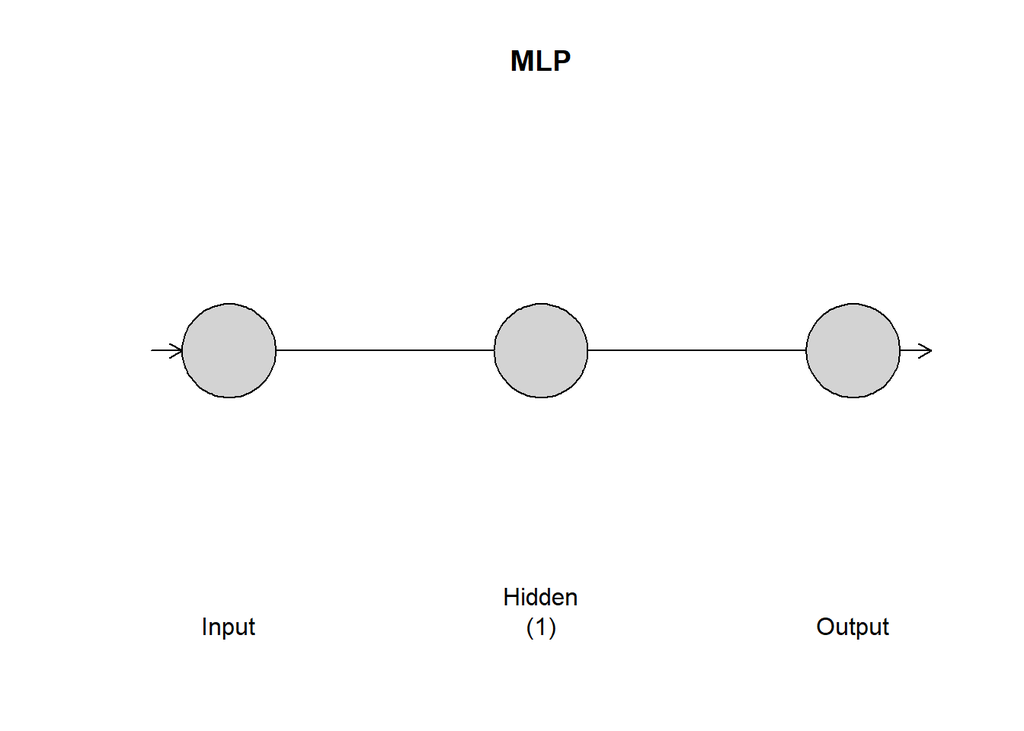

```r
#Plot Final Model
plot(caret_model.u$finalModel)
```

Nothing too fancy here. Running the model to get forecasts based on the recommended hyperparameters, we will use the median since there are so few repetitions and we don’t want the final model to be heavily influenced by outliers.

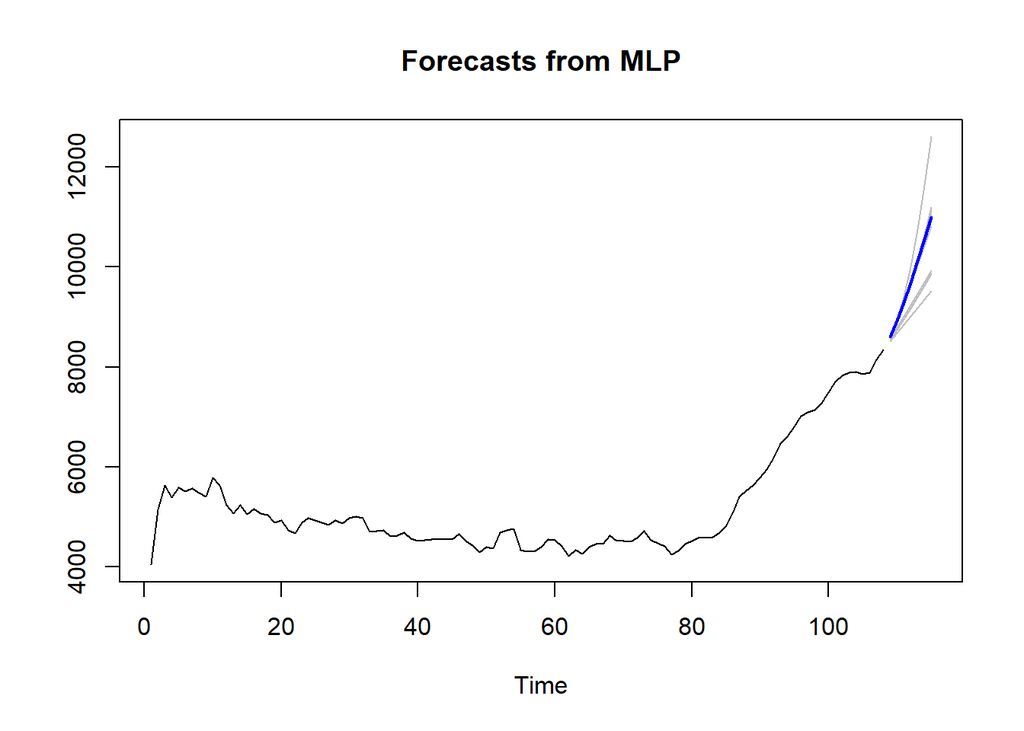

```r
mlp_mult2 <- mlp(tsth, reps = 16, hd=1, comb = "median", xreg = tsnc_df, allow.det.season = FALSE)
fore_mlp_mult_7 <- forecast(mlp_mult2, h=7, xreg = case_df) #1 week mlp forecast
plot(fore_mlp_mult_7)
```

The tuning process produced a model with a more drastic increasing trend than the model useing default parameters. Because of the constant increasing trend, we would again only use this model in a 7 day forecast.

Again for consistent comparison, this model was run reserving the last 7 observations to calculate the ASE against a 7 day forecast.

```r
#create time series objects and dataframes for shortened data
tsth_train <- ts(Totalhosp1[1:101])
tsnc_train <- ts(newcases_7dayavg1[1:101])
tsnc_df_t <- data.frame(tsnc_train)
casedf_t <- data.frame(newcases_7dayavg1)
#model hospitalizations with mlp on shortened set
mlp_mult_train <- mlp(tsth_train, reps = 16, hd=1, comb = "median", xreg = tsnc_df_t, allow.det.season = FALSE)
fore_mlp_mult_7_ASE <- forecast(mlp_mult_train, h=7, xreg = casedf_t) #1 week mlp forecast overlay for ASE

#Calculate ASE
ASE = mean((Totalhosp1_test - fore_mlp_mult_7_ASE$mean)^2)
ASE
```

```
## [1] 272510.1
```

We can see again that the dip at the end of the data is causing the differences. The forecast follows the trend at the end of the data.

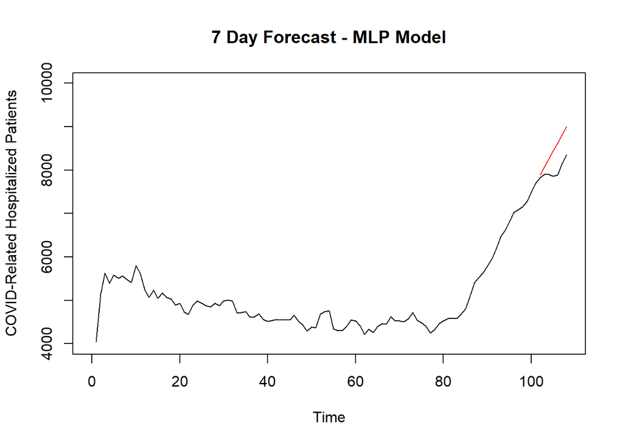

```r
plot(Time, Totalhosp1, type = "l",xlim = c(0,108),  ylim = c(4000,10000), ylab = "COVID-Related Hospitalized Patients", main = "7 Day Forecast - MLP Model")
lines(seq(102,108,1), fore_mlp_mult_7_ASE$mean, type = "l", col = "red")
```

## California: Quantitative Model Comparison by ASE

##### Univariate Models

- ARMA(1,2) Stationary Model: 178,260
- ARIMA(0,0,0) with d=2 (Non-stationary) Model: 379,683
- Univariate MLP Ensemble (Mean) Model: 92,395

## California: Model Selections and Conclusions on Forecasting Current Hospitalized COVID Patients

Traditional methods for generating time series models for forecasting actually have very limited usefulness in this particular scenario with Hospitalized COVID-19 patients in California. Our analysis operated under the assumption that the number of cases and hospitalizations, regardless of any current trend, must eventually decline back to (nearly) zero if COVID-19 is to be considered as a novel virus. At the current time, hospitalizations are increasing in California, so non-stationary models generated based on past data continue this trend. Since we believe that a constant (or in the case of some of the models seen in this analysis, an exponentially) increasing trend is unlikely to continue for the next three months, none of these non-stationary models can be used for forecasting more than a few days. We’ve deemed this assumption to be reasonable based solely on our opinion formed from the past trends we’ve witnessed.

It is for this reason that the best model we have from this analysis for a three month forecast is the stationary ARMA(1,2) model that drives the forecast back toward the mean of the data we have.

For a one week forecast, the univariate MLP had the lowest ASE, but the multiple linear regression model using the last 7-day average of new positive cases had the lowest ASE of the multivariate models. Because of the volatility of future behaviour of this data, we don’t think that the model with lowest ASE is necessarily the best for forecasting. One advantage of the MLR model is that by using the average of the last 7 days of new cases as a predictor along with the current trend, we get a good blend of weighing future changes in hospitalizations based on its past behaviour and by the number of new cases. We learned from this model that there is a correlation between these two variables, but we could see in the plot of them that new cases went from being lower on the curve to crossing over and being higher on the curve than the number of hospitalized COVID patients. This could indicate that the number of new cases could become a poor predictor in the future, and we touched on this as part of our decision to not model new cases as the best indicator of virus severity. However for the next seven days, we would like to use the model that includes this predictor so we’ll go with the MLR model.

3 month Forecast with ARMA(1,2) model

```r
fq <- fore.arma.wge(Totalhosp, phi = Hosp_estq$phi, theta = Hosp_estq$theta, n.ahead = 90, lastn = FALSE, limits = TRUE)
```

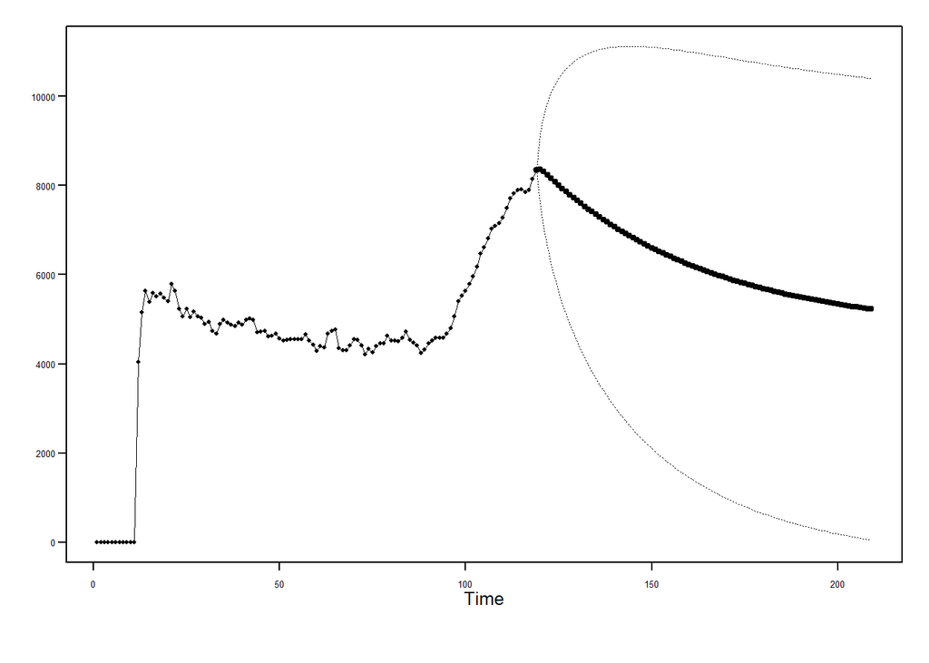

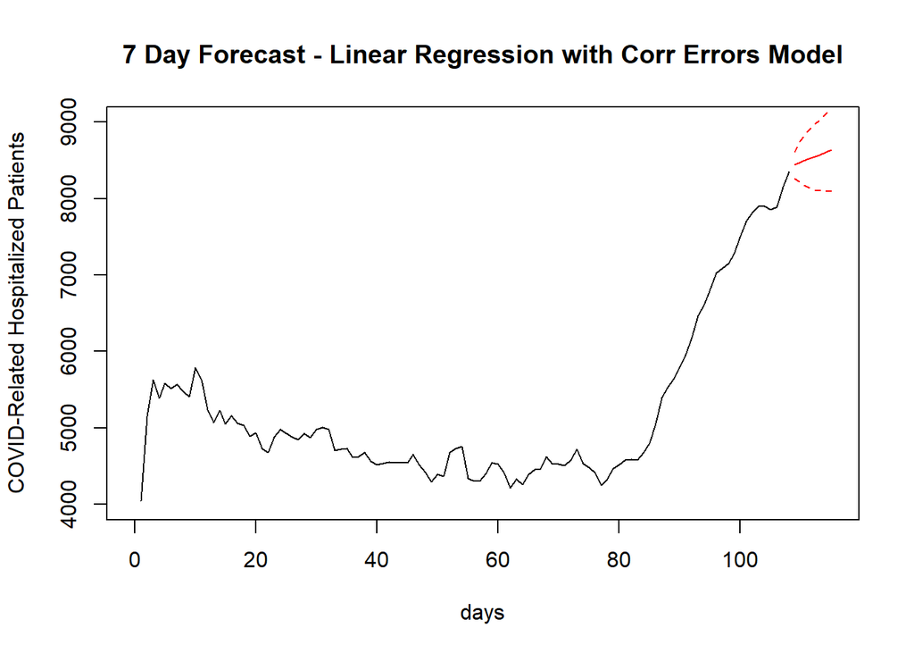

```r
plot(seq(1,108,1), Totalhosp1, type = "l",xlim = c(0,115),ylim=c(4000,9000), xlab="days", ylab = "COVID-Related Hospitalized Patients", main = "7 Day Forecast - Linear Regression with Corr Errors Model")
lines(seq(109,115,1), f_mlr2$pred, type = "l", col = "red")
lines(seq(109,115,1), (f_mlr2$pred+f_mlr2$se), type = "l", col = "red",lty = 2)
lines(seq(109,115,1), (f_mlr2$pred-f_mlr2$se), type = "l", col = "red",lty = 2)
```